# Multiple regression model

### Maria Ines Aran - March 2020

# What factors affect the quality of life in patients with Chronic Obstructive Pulmonary disease?

Background: The Chronic Obstructive Pulmonary (COPD) disease is a type of obstructive lung disease characterized by long-term breathing problems and poor airflow. It is a progressive condition. Understanding the factors that decrease the quality of life of patients with COPD might help improve a patient’s daily condition.

I have done this analysis as part of the Statistical Analysis with R for Public Health Specialization (Imperial College London).

Methods: 101 patients diagnosed with COPD who have completed the SGRQ questionnaire were considered in the study. Multiple linear regression was adjusted with age, gender, COPD severity, forced expiratory volume (FEV1), smoker and comorbidities as predictors.

Data is simulated.

Results: The model only explained 17% of the variation in the sample. The predictors do not explain the variation in the quality of life in patients with COPD in this sample.

Discussion: The model can be improved adding new variables. The results are valid only for this sample and cannot be extrapolated to the entire.

The Chronic Obstructive Pulmonary disease is a type of obstructive lung disease characterized by long-term breathing problems and poor airflow. COPD is a progressive disease, meaning it typically worsens over time. Eventually, everyday activities such as walking or getting dressed become difficult.

The purpose of this analysis is to understand the factors that reduce the quality of life in patients with COPD.

The SGRQ questionnaire addresses the frequency of respiratory symptoms and the patient’s state. It is used as a proxy of the quality of life and it is the output of the model.

```r
library(ggplot2)
library(ggthemes)
library(kableExtra)
library(tidyverse)
library(corrplot)
library("PerformanceAnalytics")
library(Hmisc)
library(sjPlot)
library(gmodels)
library(mctest)
library(prediction)
library("VIM")
library(ggridges)
library(grid)
library(gridExtra)
options(scipen = 999)

# Working directory
setwd("~/Documents/cursos/Health_statistics_Imperial_college")

# Read data
COPD <- read.csv('linear_data.csv')

# Size
#dim(COPD)
```

## Data

The dataset contains data on 101 patients diagnosed with COPD.

The variable of interest is the quality of life measured by the St. George’s Respiratory Questionnaire (SGRQ) score.

The dataset contains information about patient’s age, gender, comorbidities (diabetes, muscular disease, hypertension, IHD and atrial fibrillation) and measurements such as the walking distance (MWT1, MWT2, MWTBest), Forced Vital Capacity (FVC), Forced expiratory volume (FEV1) and smoking habits.

```r
# Head
kable(head(COPD)[,1:12], 'html') %>%
  kable_styling(full_width = F)
```

| X | ID | AGE | PackHistory | COPDSEVERITY | MWT1 | MWT2 | MWT1Best | FEV1 | FEV1PRED | FVC | FVCPRED |
| --- | --- | --- | --- | --- | --- | --- | --- | --- | --- | --- | --- |
| 1 | 58 | 77 | 60 | SEVERE | 120 | 120 | 120 | 1.21 | 36 | 2.40 | 98 |
| 2 | 57 | 79 | 50 | MODERATE | 165 | 176 | 176 | 1.09 | 56 | 1.64 | 65 |
| 3 | 62 | 80 | 11 | MODERATE | 201 | 180 | 201 | 1.52 | 68 | 2.30 | 86 |
| 4 | 145 | 56 | 60 | VERY SEVERE | 210 | 210 | 210 | 0.47 | 14 | 1.14 | 27 |
| 5 | 136 | 65 | 68 | SEVERE | 204 | 210 | 210 | 1.07 | 42 | 2.91 | 98 |
| 6 | 84 | 67 | 26 | MODERATE | 216 | 180 | 216 | 1.09 | 50 | 1.99 | 60 |

```r
kable(head(COPD)[,13:24], 'html') %>%
  kable_styling(full_width = F)
```

| CAT | HAD | SGRQ | AGEquartiles | copd | gender | smoking | Diabetes | muscular | hypertension | AtrialFib | IHD |
| --- | --- | --- | --- | --- | --- | --- | --- | --- | --- | --- | --- |
| 25 | 8 | 69.55 | 4 | 3 | 1 | 2 | 1 | 0 | 0 | 1 | 0 |
| 12 | 21 | 44.24 | 4 | 2 | 0 | 2 | 1 | 0 | 0 | 1 | 1 |
| 22 | 18 | 44.09 | 4 | 2 | 0 | 2 | 1 | 0 | 0 | 1 | 0 |
| 28 | 26 | 62.04 | 1 | 4 | 1 | 2 | 0 | 0 | 1 | 1 | 0 |
| 32 | 18 | 75.56 | 1 | 3 | 1 | 2 | 0 | 1 | 1 | 0 | 0 |
| 29 | 21 | 73.82 | 2 | 2 | 0 | 1 | 1 | 0 | 0 | 1 | 0 |

## Data preparation and feature engineering

A comorbid feature is created to consider if the patient suffered at least from one of the comorbidities in the dataset: diabetes, muscular, hypertension, atrial fibrillation and IHD.

```r
# Set categorical variables to factors
COPD$gender <- factor(COPD$gender)
COPD <- COPD %>% mutate(smoking = case_when(smoking == 2 ~ '1',
                                            smoking == 1 ~ '0',
                                            TRUE ~ as.character(smoking)))
COPD$smoking <- factor(COPD$smoking)

# COPD Severity: join 'SEVER' and 'VERY SEVERE' as is has few cases
COPD <- COPD %>% mutate(COPDSEVERITY = case_when(COPDSEVERITY == 'VERY SEVERE' ~ 'SEVERE',
                                         TRUE ~ as.character(COPDSEVERITY)))
COPD$COPDSEVERITY <- factor(COPD$COPDSEVERITY)

# Comorbid variable

# List categorical variables
categorical <- c('Diabetes','muscular','hypertension','AtrialFib','IHD')

# Transform to factors
#COPD[,categorical] <- data.frame(apply(COPD[categorical],2,as.factor))

# Create comorbid
COPD <- COPD %>% mutate(comorbid = ifelse(Diabetes +
                                          muscular +
                                          hypertension +
                                          AtrialFib +
                                          IHD > 0, 1,0))
# Transform fo factor
COPD$comorbid <- factor(COPD$comorbid)
```

There are no missing values in the selected variables for modelling.

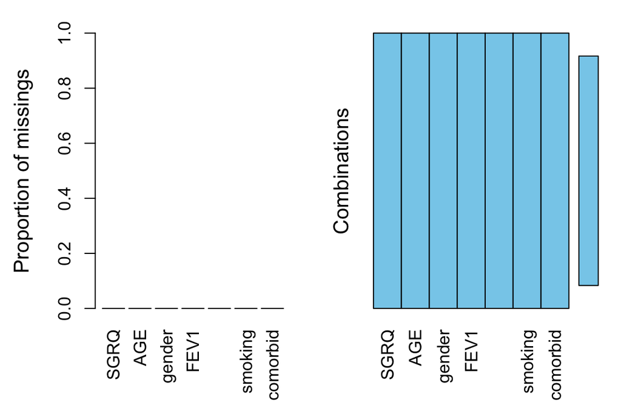

```r
# Check missing values
COPD %>%
  select(SGRQ,AGE,gender,FEV1,COPDSEVERITY,smoking,comorbid) %>%
  aggr() # Missing
```

## Exploratory analysis

The St. George’s Respiratory Questionnaire (SGRQ) scores range from 0 - 100 with higher scores indicating more limitations. In this sample, the mean is 40.29, 1st Quartile is 28.41 and 3rd Quartile is 55.23.

The SGPQ follows a normal distribution, tested by the Shapiro-Wilk normality test (W-Statistic 0.97 and p-value of 0.09).

A set of variables was selected as candidates for predictors: age, gender, comorbid, COPD severity, FEV1 and a binary variable indicating if the patient is an ex or current smoker.

The age distribution is left-skewed as COPD affects the oldest population the most.

```r
# Summary
summary(COPD$SGRQ)
summary(COPD$AGE)

# Normality test
shapiro.test(COPD$SGRQ)
```

[output not shown]

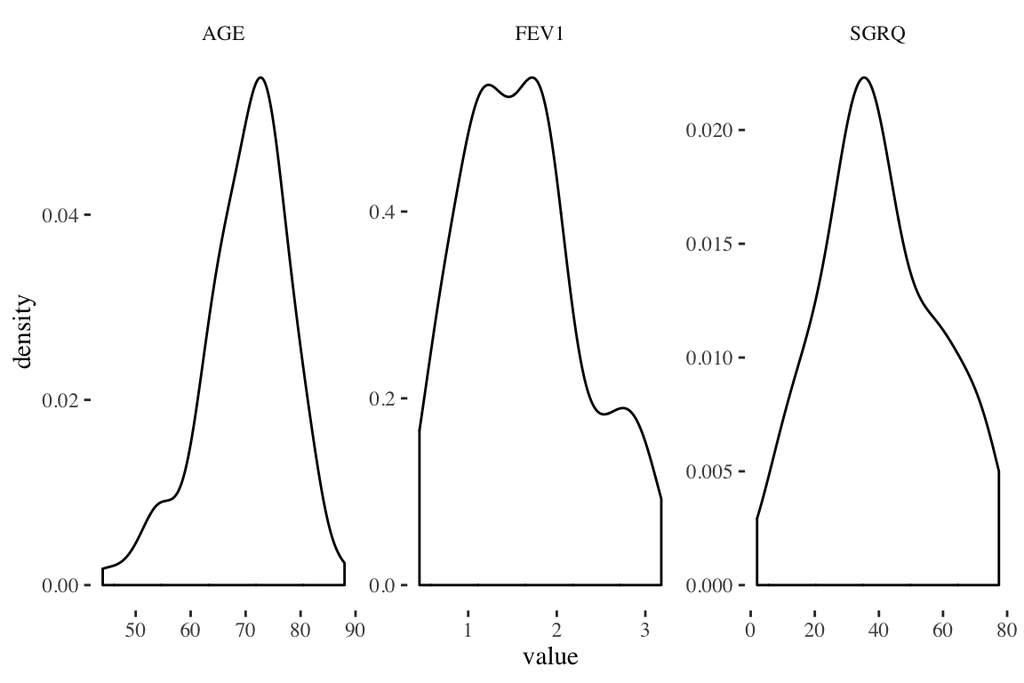

```r
COPD %>%
  select(SGRQ,AGE,gender,FEV1,COPDSEVERITY,smoking,comorbid) %>% # selected variables
  keep(is.numeric) %>%                     # Keep only numeric columns
  gather() %>%                             # Convert to key-value pairs
  ggplot(aes(value)) +                     # Plot the values
    facet_wrap(~ key, scales = "free") +   # In separate panels
    geom_density() +                       # as density
  theme_tufte()
```

The correlation plot shows that there is a weak linear correlation between FEV1 and SGRQ.

Other variables show a very weak correlation.

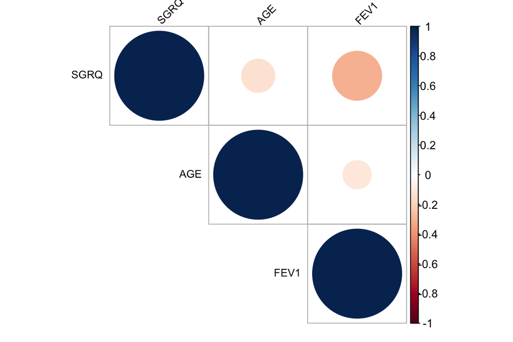

```r
# Correlation matrix
res <- cor(COPD %>%  select(SGRQ,AGE,gender,FEV1,COPDSEVERITY,smoking) %>% keep(is.numeric), use = 'na.or.complete')

# Correlation plot
corrplot(res, # Correlation matrix
         type = "upper", # Triangle part to display
         order = "hclust",
         tl.col = "black", tl.srt = 45,
         tl.cex = 0.75) # Font Size
```

Patients in the sample are mostly equally distributed according to COPD severity (42% Moderate, 34% Severe and 22% Mild). The distribution of patients with severe COPD is more skewed to the left, meaning that their SGRQ is higher and thus they suffered more limitations.

There are more men (64%) than women (35%) in the sample and the distribution of SPQR score is similar.

84% of the patients are current smokers and their SPQR score follows a normal distribution.

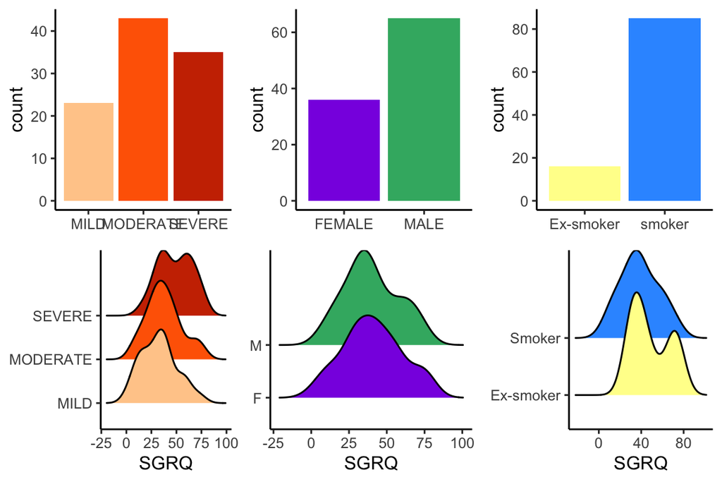

```r
# Categorical
p1 <- ggplot(COPD, aes(COPDSEVERITY, fill = COPDSEVERITY)) +
      geom_bar() +
      scale_colour_manual(values = c('#FFCC99','#FF6600','#CC3300'), aesthetics = c('colour','fill')) +
      theme_classic() +
      theme(axis.title.x = element_blank(),
            legend.position = 'None')
p2 <- ggplot(COPD, aes(x = SGRQ, y = COPDSEVERITY)) +
      geom_density_ridges(aes(fill = COPDSEVERITY)) +
      scale_colour_manual(values = c('#FFCC99','#FF6600','#CC3300'), aesthetics = c('colour','fill')) +
      theme_classic() +
      theme(legend.position = 'None',
            axis.title.y = element_blank())

p3 <- ggplot(COPD, aes(gender, fill = gender)) +
      geom_bar() +
      scale_x_discrete(labels = c('FEMALE','MALE')) +
      scale_colour_manual(values = c('#8A2BE2','mediumseagreen'), aesthetics = c('colour','fill')) +
      theme_classic() +
      theme(axis.title.x = element_blank(),
            legend.position = 'None')
p4 <- ggplot(COPD, aes(x = SGRQ, y = gender)) +
      geom_density_ridges(aes(fill = gender)) +
      scale_y_discrete(labels = c('F','M')) +
      scale_colour_manual(values = c('#8A2BE2','mediumseagreen'), aesthetics = c('colour','fill')) +
      theme_classic() +
      theme(legend.position = 'None',
            axis.title.y = element_blank())

p5 <- ggplot(COPD, aes(smoking, fill = smoking)) +
      geom_bar() +
      scale_x_discrete(labels = c('Ex-smoker','smoker')) +
      scale_colour_manual(values = c('#FFFF99','#3399FF'), aesthetics = c('colour','fill')) +
      theme_classic() +
      theme(axis.title.x = element_blank(),
            legend.position = 'None')
p6 <- ggplot(COPD, aes(x = SGRQ, y = smoking)) +
      geom_density_ridges(aes(fill = smoking)) +
      scale_y_discrete(labels = c('Ex-smoker','Smoker')) +
      scale_colour_manual(values = c('#FFFF99','#3399FF'), aesthetics = c('colour','fill')) +
      theme_classic() +
      theme(legend.position = 'None',
            axis.title.y = element_blank())


grid.arrange(p1,p3,p5,p2,p4,p6, nrow = 2)
```

```r
prop.table(table(COPD$COPDSEVERITY))
prop.table(table(COPD$gender))
prop.table(table(COPD$smoking))
```

[output not shown]

# Model

Multiple regression was fitted with SGRQ as outcome and age, gender, FEV1, smoker, comorbid and COPD severity as predictors.

Adjusted R-squared (0.17) indicates that the model fits the data poorly as it only explains 17% of the variability.

The outcome also increases as the COPD severity worsens, although this result is not statistically significant.

```r
modelfit <- lm(SGRQ ~ AGE + gender + FEV1 + smoking + COPDSEVERITY + comorbid, data = COPD)

table <- sjPlot::tab_model(modelfit,
                  dv.labels = c('Quality of Life'),
                  p.style = 'a')
table
```

Quality of Life

Predictors

Estimates

CI

(Intercept)

69.68 ***

30.25 – 109.10

AGE

-0.35

-0.80 – 0.10

gender [1]

1.07

-7.51 – 9.66

FEV1

-3.48

-12.71 – 5.75

smoking [1]

-11.87 *

-21.19 – -2.56

COPDSEVERITY [MODERATE]

4.92

-5.61 – 15.44

COPDSEVERITY [SEVERE]

12.97

-2.59 – 28.52

comorbid [1]

5.93

-0.87 – 12.74

Observations

101

R<sup>2</sup> / R<sup>2</sup> adjusted

0.224 / 0.166

- p<0.05 ** p<0.01 *** p<0.001

## Multiple regression assumptions

A linear regression model was fitted to address the relationship between SGRQ and predictors. A few assumptions are made when a linear model is fitted and we need to check if they are met to conclude from the model estimates.

### Errors are normally distributed

The errors between observed and predicted values are normally distributed, as plotted in the Q-Q Plot where most of the dot lies over the line.

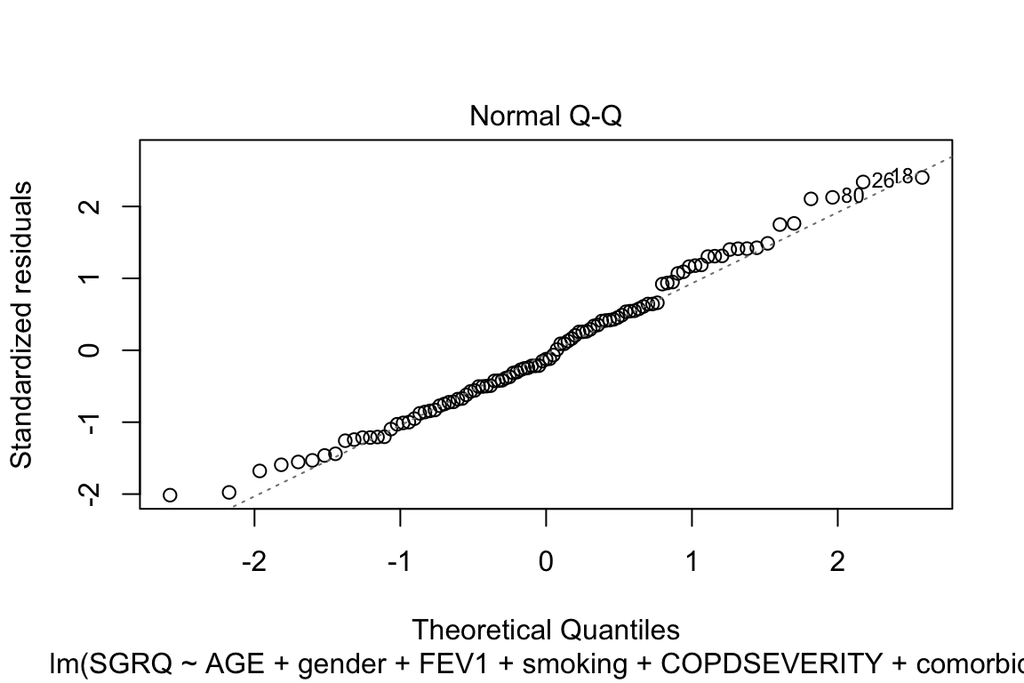

```r
# Check model assumptions
#par(mfrow=c(2,2))
plot(modelfit, which = 2:2)
```

### Multicollinearity

The independent variables should not be highly correlated with each other.

The Variance inflator factor (VIF) shows the degree that the variances in the estimates are increased due to multicollinearity. As VIF is smaller than 4 for all the variables, the no multicollinearity assumption is met.

```r
# Variance inflation factor
model <- lm(SGRQ ~ AGE + gender + FEV1 + smoking + COPDSEVERITY + comorbid, data = COPD)
table <- car::vif(model)

kable(table, 'html') %>%
  kable_styling(position = "center")
```

|  | GVIF | Df | GVIF^(1/(2*Df)) |
| --- | --- | --- | --- |
| AGE | 1.150366 | 1 | 1.072551 |
| gender | 1.561594 | 1 | 1.249637 |
| FEV1 | 3.524018 | 1 | 1.877237 |
| smoking | 1.067067 | 1 | 1.032989 |
| COPDSEVERITY | 3.301193 | 2 | 1.347931 |
| comorbid | 1.059937 | 1 | 1.029532 |

### Homosecedasticity

The homoscedasticity assumption refers to the fact that the variance around the fitted line is the same for all values of the predictors.

There is no clear pattern in the distribution of fitted and residual values, so the homoscedasticity assumption is met.

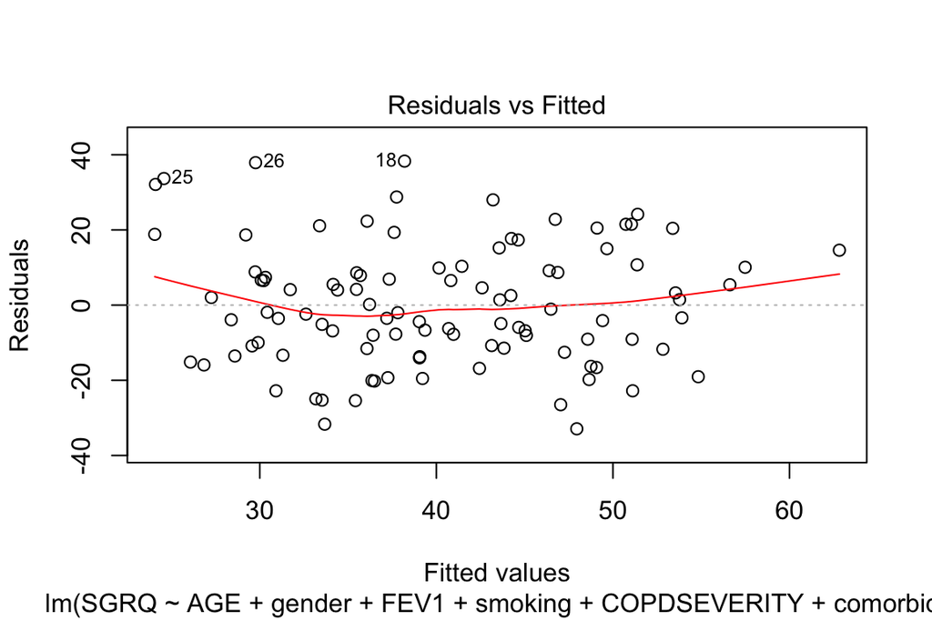

```r
# Check model assumptions
#par(mfrow=c(2,2))
plot(modelfit, which = 1:1)
```

# Result

Done by [Maria Ines Aran](https://github.com/aranmariaines/)

*aranmariaines@gmail.com*